# Coursework project

## on the module 1 “The Datascientist’s Toolbox”

### **done by Alexandra Avdan**

#### *July 2023*

> This project is available in the public repository on GitHub. You can check it following this [**link**](https://github.com/AlexashaSova/module1_coursework_avdan.git).

The first step of this project is to load and analyze three datasets from the pre-installed R package **‘datasets’**. The full list of packages, available at the named package, is available in the [**link to the R documentation**](https://stat.ethz.ch/R-manual/R-devel/library/datasets/html/00Index.html). From the named library it was decided to pick 3 datasets by my own preferences to analyze data each of the selected datasets contains.

> Respecting to the fact, that our knowledge is not deep enough to build complex analysis, in my work is represented only brief look on each of datasets, within the basics of the descriptive analysis with the elements of exploratory approach in order to find some possible dependencies of the given data.
- The first dataset is pretty classical dataset for this subject area, **‘iris’**. This dataset represents measurements of *sepal length*, *sepal width*, *petal length* and *petal width* of the three iris species: *setosa*, *virginica* and *versicolor*. There are 50 rows per each of the iris species in the dataset.

```r
# get the data of the whole dataset
library(datasets)
data("iris")
```

On the image below are represented top 12 rows of the iris dataset, ordered by index at the ascending order.

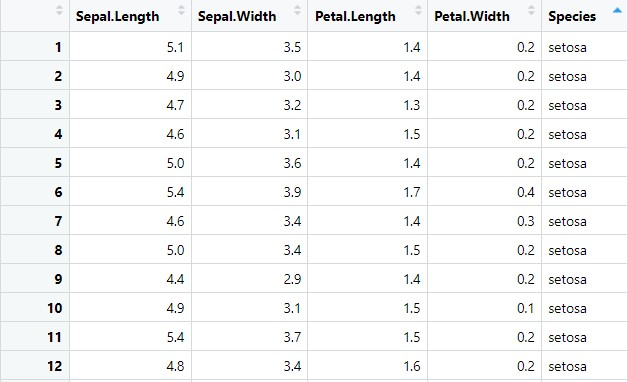

The next step is to obtain summary on the dataset.

The following summary contains values on the criteria, such as

- *minimum (Min.)*,
- *1st Quartile (1st Qu.)* (i.e. 25% of data was taken under the produced value),
- *Median* (can be named as a middle value of some numeric sequence),
- *Mean* (average value),
- *3rd Quartile (3rd Qu.)* (i.e. 75% of data was taken under the produced value),
- *maximum (Max.)*

  for **numeric values** and
- *number of occurencies* of each value

  for **string values** (column *‘Species’* in *iris* dataset).

Additionally, the range value can be calculated if needed. However, without any certain question, needed to be solved, these values are useless. According to the dataset data, this dataset has no missing values (no NaN or NULLs).

```r
summary(iris)
```

```
##   Sepal.Length    Sepal.Width     Petal.Length    Petal.Width
##  Min.   :4.300   Min.   :2.000   Min.   :1.000   Min.   :0.100
##  1st Qu.:5.100   1st Qu.:2.800   1st Qu.:1.600   1st Qu.:0.300
##  Median :5.800   Median :3.000   Median :4.350   Median :1.300
##  Mean   :5.843   Mean   :3.057   Mean   :3.758   Mean   :1.199
##  3rd Qu.:6.400   3rd Qu.:3.300   3rd Qu.:5.100   3rd Qu.:1.800
##  Max.   :7.900   Max.   :4.400   Max.   :6.900   Max.   :2.500
##        Species
##  setosa    :50
##  versicolor:50
##  virginica :50
##
##
##
```

From the data below it is clear that all the metrics are calculated on all the iris species. It would be more informative, if the metrics were calculated on the certain needed iris type. Assume, we need to get some metrics on the iris *setosa*. Let’s create dataframe with *setosa* values **only**.

```r
# attaching library dplyr to use filter() function
library(dplyr)
# to make it more usable to call the names of the columns making it to lowercase
names(iris) <- tolower(names(iris))
# creating dataframe with setosa rows only
setosa <- filter(iris, species == "setosa")
# show top-6 values of the obtained dataframe ordered by the ascending of the index
head(setosa)
```

|  | sepal.length | sepal.width | petal.length | petal.width | species |
| --- | --- | --- | --- | --- | --- |
| 1 | 5.1 | 3.5 | 1.4 | 0.2 | setosa |
| 2 | 4.9 | 3.0 | 1.4 | 0.2 | setosa |
| 3 | 4.7 | 3.2 | 1.3 | 0.2 | setosa |
| 4 | 4.6 | 3.1 | 1.5 | 0.2 | setosa |
| 5 | 5.0 | 3.6 | 1.4 | 0.2 | setosa |
| 6 | 5.4 | 3.9 | 1.7 | 0.4 | setosa |

The next step is obtaining summary metrics on the measurements of different *setosa* irises. According to the data of the column *‘species’* there are no other data here, except from *setosa* data. The obtained metrics’ data also differ from the previously obtained.

```r
summary(setosa)
```

```
##   sepal.length    sepal.width     petal.length    petal.width
##  Min.   :4.300   Min.   :2.300   Min.   :1.000   Min.   :0.100
##  1st Qu.:4.800   1st Qu.:3.200   1st Qu.:1.400   1st Qu.:0.200
##  Median :5.000   Median :3.400   Median :1.500   Median :0.200
##  Mean   :5.006   Mean   :3.428   Mean   :1.462   Mean   :0.246
##  3rd Qu.:5.200   3rd Qu.:3.675   3rd Qu.:1.575   3rd Qu.:0.300
##  Max.   :5.800   Max.   :4.400   Max.   :1.900   Max.   :0.600
##        species
##  setosa    :50
##  versicolor: 0
##  virginica : 0
##
##
##
```

The final step is creating visualizations. Note, that there was no particular aim, set as a goal of investigations. The first visualization is done on the whole *iris* dataset. From the visualization below some conclusions could be made:

- it was a bad practice to visualize the whole dataset, that contains both numeric and string values. The obtained row and column ‘species’ is not pretty informative;
- it is useful to assess the whole picture of the dataset, but for more accurate conclusions and results, more detailed visualizations have to be made.

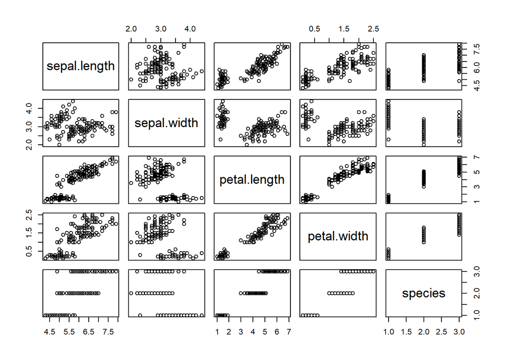

```r
plot(iris)
```

Let’s create a visualization of the created *setosa* data **only** dataframe. The obtained visualization allows to make conclusions and analysis on the certain type of iris flowers *setosa*. For this graph comments and observation are the same, as for the previous one.

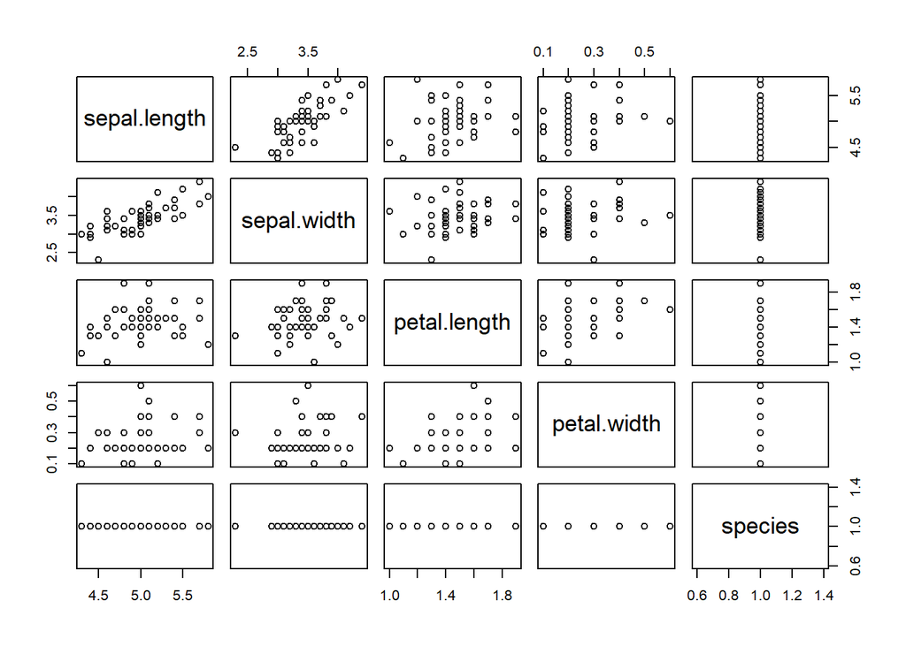

```r
plot(setosa)
```

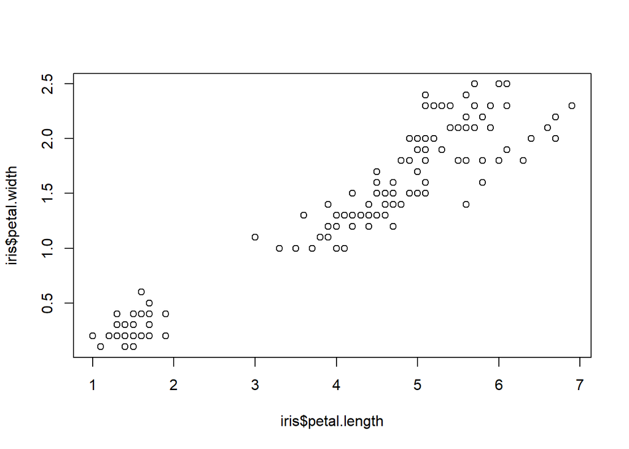

```r
plot(iris$petal.length, iris$petal.width)
```

More investigations can be made with the formulated question to solve.